# Отчёт по лабораторной работе №4

Установка и настройка Git и git-flow

Автор

принадлежность

Терентеевская Светлана Александровна, Student

Российский университет дружбы народов

Дата публикации

2026-03-07

# Информация

## Докладчик

- Терентеевская Светлана Александровна
- Группа НКАбд-05-25, студент бакалавра
- Российский университет дружбы народов им. П. Лумумбы
- 1032253498@rudn.ru
- https://github.com/SvetlanaTerenteevskaya

# Вводная часть

## Цель работы

Получить навыки правильной работы с репозиториями git.

## Задание

- Выполнить работу для тестового репозитория
- Преобразовать рабочий репозиторий в репозиторий с git-flow и conventional commits

## Теоретическое введение

Gitflow Workflow опубликована и популярована Винсентом Дриссеном. Gitflow Workflow предполагает выстраивание строгой модели ветвления с учётом выпуска проекта. Данная модель отлично подходит для организации рабочего процесса на основе релизов. Работа по модели Gitflow включает создание отдельной ветки для исправлений ошибок в рабочей среде.

Последовательность действий при работе по модели Gitflow:

1. Из ветки `master` создаётся ветка `develop`.
2. Из ветки `develop` создаётся ветка `release`.
3. Из ветки `develop` создаются ветки `feature`.
4. Когда работа над веткой `feature` завершена, она сливается с веткой `develop`.
5. Когда работа над веткой релиза `release` завершена, она сливается в ветки `develop` и `master`.
6. Если в `master` обнаружена проблема, из `master` создаётся ветка `hotfix`.
7. Когда работа над веткой исправления `hotfix` завершена, она сливается в ветки `develop` и `master`.

# Выполнение лабораторной работы

## Установка программного обеспечения

Я скачала установщик и через него установила gitflow (рис. 1).

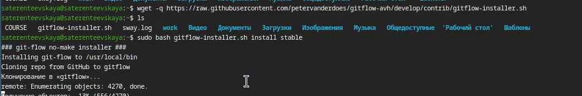

Рисунок 1: Установка git-flow

Удалила установщик (рис. 2).

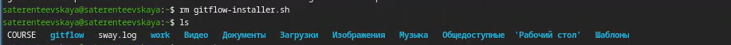

Рисунок 2: Удаление установщика

Далее я установила Node.js (рис. 3).

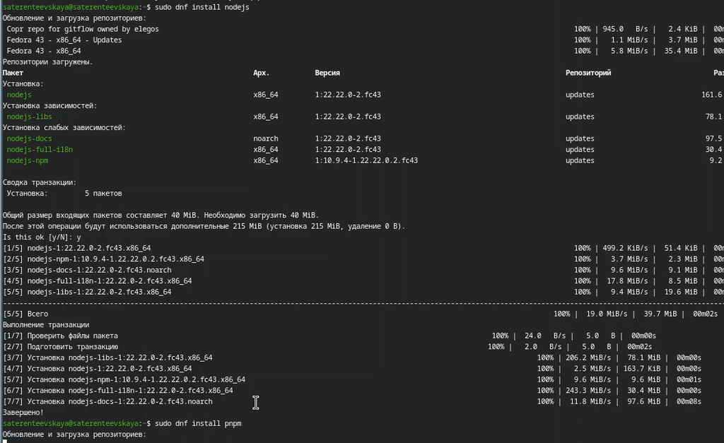

Рисунок 3: Установка Node.js

Я запустила pnpm setup и выполнила source ~/.bashrc (рис. 4).

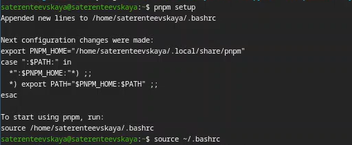

Рисунок 4: Настройка Node.js

Я установила пакет commitizen (рис. 5).

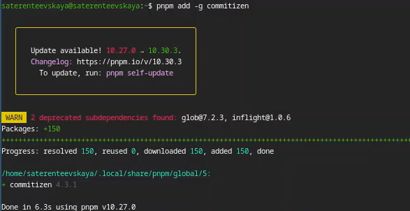

Рисунок 5: Скачивание пакета

И скачала программу, которая используется для помощи в создании логов (рис. 6).

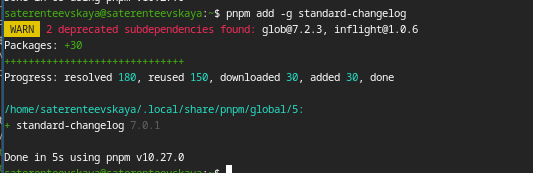

Рисунок 6: Скачивание программы для помощи в создании логов

## Практический сценарий использования git

Я создала репозиторий на GitHub и назвала его git-extended (рис. 7).

[figure not shown]

Рисунок 7: Создание репозитория

Перешла в созданный каталог и выполнила первый коммит, но поскольку не было никаких изменений, выдало : нечего комитить (рис. 8).

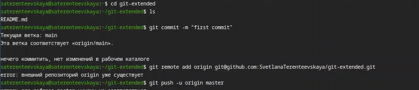

Рисунок 8: Выполнение коммита

После этого я перешла к конфигурации для пакетов Node.js (рис. 9).

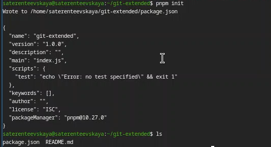

Рисунок 9: Конфигурация для пакетов Node.js

Изменила текст в файле package.json, добавив в него команду для формирования коммитов (рис. 10).

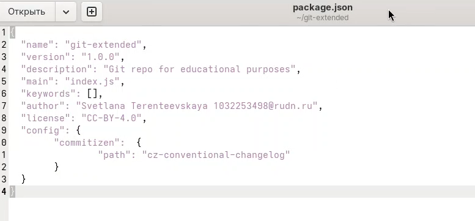

Рисунок 10: Изменение команды

Добавила новые файлы, выполнила коммит и отправила на GitHub (рис. 11).

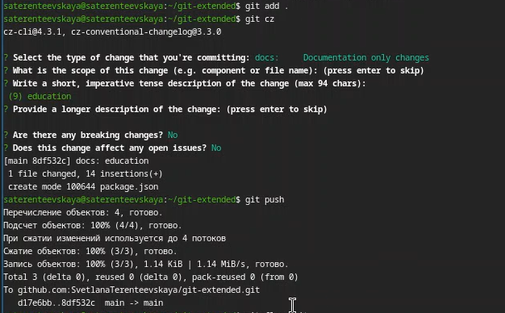

Рисунок 11: Добавление файлов и отправка на GitHub

Далее я инициализировала git-flow, установила префикс для ярлыков -v, проверила, что нахожусь на ветке develop и загрузила весь репозиторий в хранилище (рис. 12).

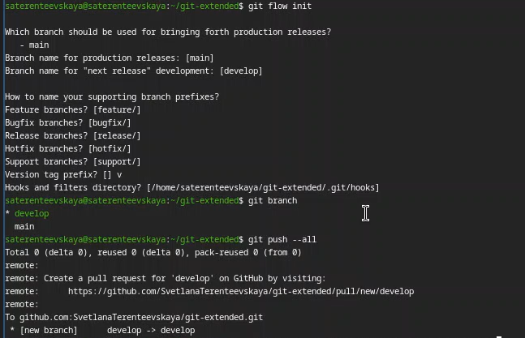

Рисунок 12: Инициализация git-flow и загрузка репозитория в хранилище

Я установила внешнюю ветку как вышестоящую для этой ветки и создала релиз с версией 1.0.0 (рис. 13).

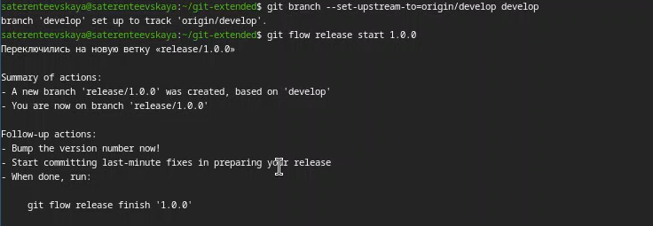

Рисунок 13: Установка ветки как вышестоящей

Создала журнал изменений, добавила журнал изменений в индекс и залила релизную ветку в основную ветку (рис. 14, рис. 15).

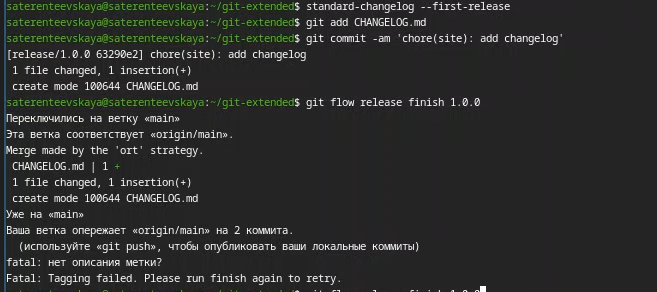

Рисунок 14: Создание журнала изменений

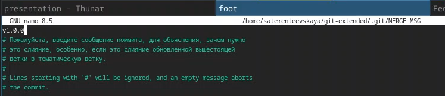

Рисунок 15: Создание журнала изменений

Отправила данные на GitHub и создала релиз на GitHub (рис. 16).

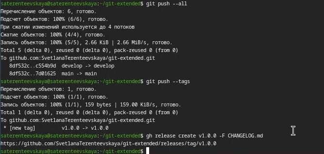

Рисунок 16: Отпарвка данных и создание релиза на GitHub

Я создала ветку для новой функциональности, проверила на какой я ветке и объединила ветки fearure_branch и develop (рис. 17).

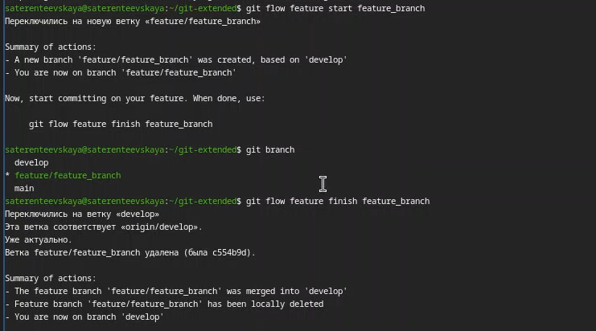

Рисунок 17: Создание ветки

Создала релиз с версией 1.2.3 (рис. 18).

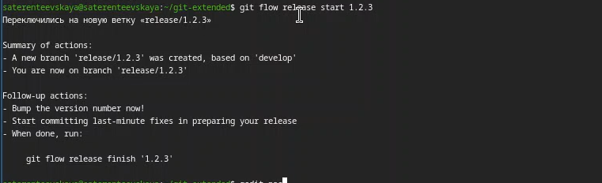

Рисунок 18: Создание релиза

Обновила номер версии в файле package.json, установив её 1.2.3 (рис. 19).

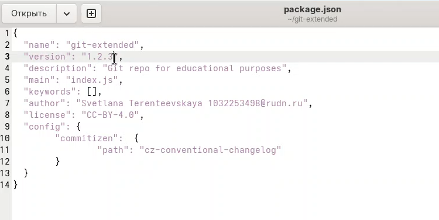

Рисунок 19: Обновление номера версии

Создала журнал изменений и добавила журнал изменений в индекс (рис. 20).

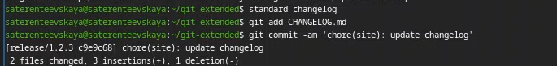

Рисунок 20: Создание журнала изменений и добавление в индекс

Залила релизную ветку в основную ветку (рис. 21, рис. 22).

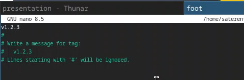

Рисунок 21: Перезалив релизнутой ветки в основную

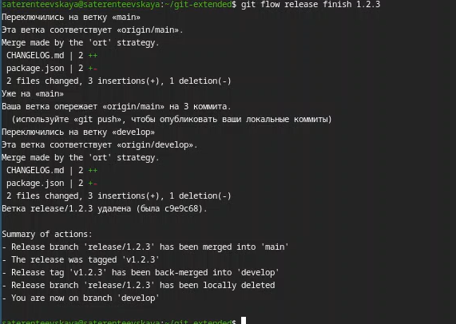

Рисунок 22: Перезалив релизнутой ветки в основную

Я отправила данные на GitHub и создала релиз с комментарием из журнала изменений (рис. 23).

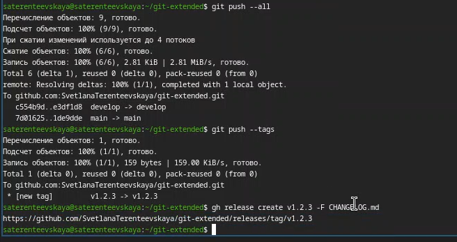

Рисунок 23: Отправка данных

Проверила, что на GitHub видны изменения (рис. 24).

[figure not shown]

Рисунок 24: Проверка изменений

# Выводы

В процессе выполнения лабораторной работы я научилась правильной работе с репозиториями git.

# Список литературы

[ТУИС](https://esystem.rudn.ru/)

[Методичка к лабораторной работе №4](https://esystem.rudn.ru/mod/page/view.php?id=1358187)